# Clase 01

**Ejercicio 1. NotasL15L2.pdf pag 37.**

*Sea $\theta$ la tasa de créditos hipotecarios otorgados por un banco. Durante el 2004 la tasa promedio fue de 60% y la desviación estándar de la tasa fue de 0.04. En lo que va del año 2005 se han solicitado 100 créditos, de los cuales se han otorgado únicamente 50.*

*a) Usando la información del año pasado encuentra la distribución beta que mejor describe el conocimiento inicial.*

Con la información del problema sabemos que $E(X) = 0.6$ y $\sqrt{Var(X)} = 0.04$. Sea X una distribución $Beta(\alpha, \beta)$, $E(X) = \frac{\alpha}{\alpha + \beta}$ y $Var(X) = \frac{\alpha\beta}{(\alpha + \beta)^2 (\alpha + \beta + 1)}$.

Entonces… si contara con el tiempo y la paciencia necesaria para hacer esto, despejaría para $\alpha$ y $\beta$ y llegaría al resultado que $\alpha = 89.4$ y $\beta = 59.6$. La cual se ve así.

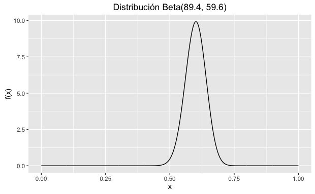

*b) Usando la información del año pasado, encuentra la distribución normal transformada que mejor describa el conocimiento inicial.*

De manera similar al inciso *a*, Sea $X \sim LogN(\mu, \sigma^2)$ entonces $E(X) = e^{(\mu + \frac{\sigma^2}{2})}$ y $Var(X) = (e^{\sigma^2} - 1)e^{2\mu + \sigma^2}$. … Si contara con la energía vital suficiente para realizar esto como se debe hacer llegaría a que los parámetros son: $\mu = .4054$ y $\sigma^2 = 33.33$, la cual se ve así:

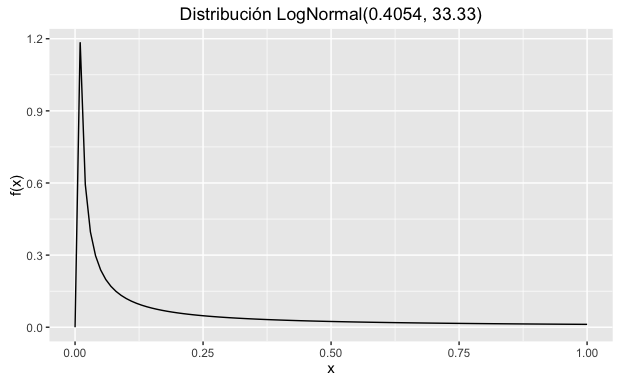

*c) Determina la distribución inicial de referencia.*

No sé qué onda aquí… pero se utiliza una $Beta(.5, .5)$ que se ve…

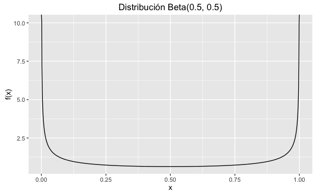

*d) Usando los datos del año 2005 encuentra la distribución final para cada una de las distribuciones iniciales de los incisos a - c.*

Utilizamos JAGS en R para implementar esta solución. La solución para cada inciso es distinta dependiendo de la distribución apriori que asignemos.

Para el inciso *a*: $Beta(89.4, 59.6)$. Para ver la implementación en JAGS ver archivo *Ej1_a.txt*.

```r
# Generamos los datos de la muestra y los guardamos en una lista
n <- 100
credito <- c(rep(1, 50), rep(0, 50))
data <- list("n" = n, "x" = credito)
inits <- function(){list(theta = 0.5, x1 = rep(1, 2))}
# Seleccionamos los parámetros que queremos monitorear
parameters <- c("theta","x1")
set.seed(1010)
ej1.sim <- jags(data, inits, parameters, model.file = "Ej1_a.txt",
                n.iter = 5000, n.chains = 1, n.burnin = 500,
                working.directory = "src/")
```

[output not shown]

```r
# Monitoreo
out <- ej1.sim$BUGSoutput$sims.list
class(out)
```

```
[1] "list"
```

```r
out$theta %>% head
```

```
          [,1]
[1,] 0.5531935
[2,] 0.5407664
[3,] 0.5706011
[4,] 0.5360304
[5,] 0.5476098
[6,] 0.5578863
```

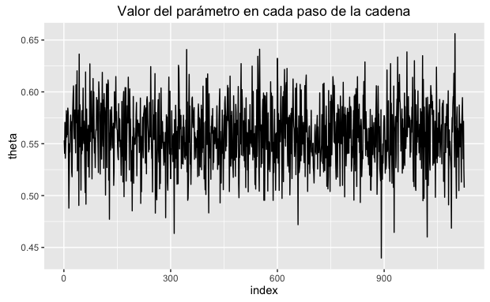

```r
ej1.theta <- out$theta %>%
  data.frame %>%
  setNames("theta") %>%
  mutate(index = 1:length(theta))
ej1.theta %>%
  ggplot(aes(index, theta)) +
  geom_line() +
  ggtitle("Valor del parámetro en cada paso de la cadena")
```

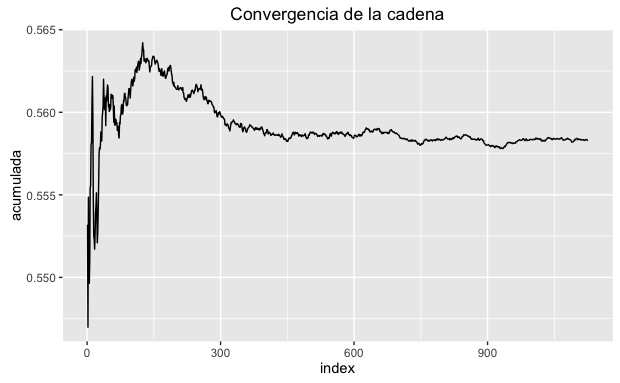

```r
ej1.theta %>%
  mutate(acumulada = cumsum(theta)/(1:length(theta))) %>%
  ggplot(aes(index, acumulada)) +
  geom_line() +
  ggtitle("Convergencia de la cadena")
```

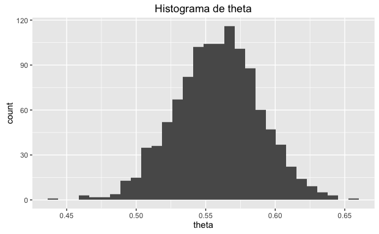

```r
ej1.theta %>%
  ggplot(aes(theta)) +
  geom_histogram() +
  ggtitle("Histograma de theta")
```

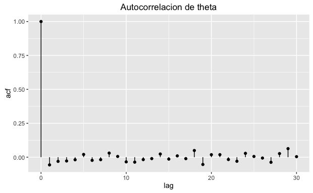

```r
data.frame(acf = acf.theta$acf,
           lag = acf.theta$lag) %>%
  ggplot(aes(lag, acf)) +
  geom_point() +
  geom_segment(aes(xend = lag, yend = 0)) +
  ggtitle("Autocorrelacion de theta")
```

Obtenemos también estadísticos básicos de los parámetros de interés.

```r
out.sum <- ej1.sim$BUGSoutput$summary
print(out.sum)
```

```
                mean         sd        2.5%        25%       50%         75%
deviance 140.3867602 1.52601424 138.6387046 139.231069 140.03726 141.1350725
theta      0.5582681 0.03053214   0.4975418   0.538633   0.55907   0.5786528
x1[1]      0.5653333 0.49593364   0.0000000   0.000000   1.00000   1.0000000
x1[2]      0.5617778 0.49638949   0.0000000   0.000000   1.00000   1.0000000
               97.5%
deviance 144.2868816
theta      0.6172644
x1[1]      1.0000000
x1[2]      1.0000000
```

Como medida de ajuste observamos el DIC.

```r
out.dic <- ej1.sim$BUGSoutput$DIC
out.dic
```

```
[1] 141.5511
```

Para los incisos restantes solamente es necesario modificar el archivo en JAGS. Omitiré el código y la validación del modelo because life, pero ahí están en el *src*.